# Time series of customer experiencing an power outage in California (2019)

Shenyue Jia

This notebook plots a time series of the number of customers experiencing a power outage (affecting 0.5% total customers) in California in 2019. Also, this notebook produced a close-up look at two major events when PSPS concurrently occurs with a major wildfire.

```r
rm(list = ls())
```

# Data preparation

- Read county-level RDS file for customer who experienced power outage time series

```r
if(any(grepl("package:plyr", search()))) detach("package:plyr",unload = TRUE) else message("plyr not loaded")
```

```
plyr not loaded
```

```r
ca_outage_df_hour <- readRDS(here("data_private",
                                  "ca_outage_customers_state_2019_10min.RDS"))
```

```r
top10_fire_df <- readRDS(here("data_private",
                              "ca_2019_top10_fire.RDS"))

top10_psps_df <- readRDS(here("data_private",
                              "ca_2019_top10_psps.RDS"))

top10_fire_df$Start <- as_date(top10_fire_df$Start)
top10_fire_df$End <- as_date(top10_fire_df$End)
top10_psps_df$Start <- as_date(top10_psps_df$Start)
top10_psps_df$End <- as_date(top10_psps_df$End)
```

- Expand top 10 fire df and top psps df to a time series
- The time series shares the same X-axis with the power outage dataframe

```r
date_stamp <- seq(as.Date("2019-01-01"), length = 365, by = "days")

fire_psps_df <- as.data.frame(date_stamp)
fire_psps_df$FireFlag <- -0.0001
fire_psps_df$PSPSFlag <- -0.0001

for (i in 1:nrow(top10_fire_df)){

  curr_start <- top10_fire_df$Start[i]
  curr_end <- top10_fire_df$End[i]

  curr_start_row <- which(fire_psps_df$date_stamp == curr_start)
  curr_end_row <- which(fire_psps_df$date_stamp == curr_end)

  fire_psps_df$FireFlag[curr_start_row:curr_end_row] <- -1


}

for (i in 1:nrow(top10_psps_df)){

  curr_start <- top10_psps_df$Start[i]
  curr_end <- top10_psps_df$End[i]

  curr_start_row <- which(fire_psps_df$date_stamp == curr_start)
  curr_end_row <- which(fire_psps_df$date_stamp == curr_end)

  fire_psps_df$PSPSFlag[curr_start_row:curr_end_row] <- -1


}
```

## Aggregate data from 10-min to hours

```r
ca_outage_df_hour <- ca_outage_df_hour %>%
  mutate(year = year(date),
         month = month(date),
         day = day(date),
         hour = hour(date),
         date = ymd_hm(paste0(year,"-",month,"-",day," ",hour,":00"))) %>%
  group_by(date) %>%
  summarise(CustomersOutState = max(CustomersOutState),
         CustomerMinutesState = sum(CustomerMinutesState),
         TotalHUState = first(TotalHUState),
         PctCustomerOutState = max(PctCustomerOutState))
```

# Plot time series

- Set up plotting theme

```r
# theme_new <- theme_set(theme_bw(base_family = "Helvetica"))
theme_new <- theme_set(theme_bw())
theme_new <- theme_update(
  legend.text = element_text(size = 10),
  axis.text = element_text(size = 8),
  axis.title = element_text(size = 10),
  plot.title = element_text(size = 12, face = "bold"),
  axis.title.x = element_blank(),
  axis.title.y.right = element_text( angle = 90))
```

- Prepare a function to create beautiful breaks

```r
  caculate_class <- function(var,nclass){
    # library(plyr)
    class_brks <- classIntervals(var, n = nclass,intervalClosure = "left",
                                 style = "pretty")
    # class <- round_any(class_brks$brks,5)
    class <- class_brks$brks

    return(class)
  }
```

- Plot the time series for 2019

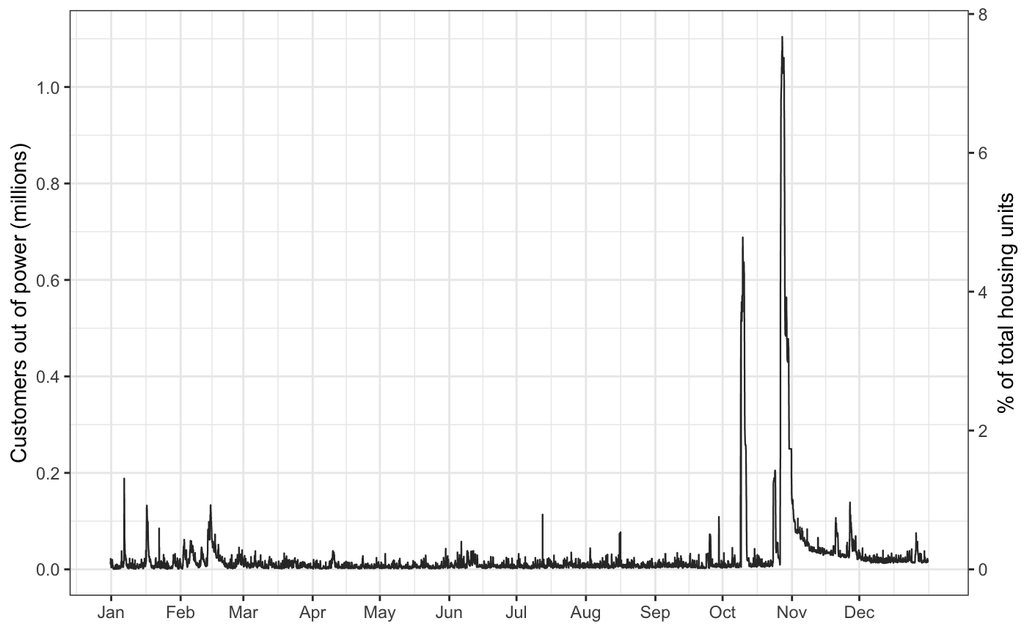

```r
breaks <- as.POSIXct(c("2019-01-01 00:00:00",
                                         "2019-02-01 00:00:00",
                                         "2019-03-01 00:00:00",
                                         "2019-04-01 00:00:00",
                                         "2019-05-01 00:00:00",
                                         "2019-06-01 00:00:00",
                                         "2019-07-01 00:00:00",
                                         "2019-08-01 00:00:00",
                                         "2019-09-01 00:00:00",
                                         "2019-10-01 00:00:00",
                                         "2019-11-01 00:00:00",
                                         "2019-12-01 00:00:00"))

ca_outage_df_hour %>%
  ggplot(aes(x=date,y=CustomersOut))+
    geom_step(data = ca_outage_df_hour, aes(x = date, y = CustomersOutState),
            size = 0.4,color = "grey20") +
  # scale_x_datetime(date_breaks = "months" ,
  #                  date_labels = "%b-%d") +
  scale_x_datetime(breaks = breaks,
                   labels = format(breaks,"%b"))+
  scale_y_continuous(
    breaks = caculate_class(ca_outage_df_hour$CustomersOutState, 5),
    labels = format(
      caculate_class(ca_outage_df_hour$CustomersOutState, 5)/1000000),
    sec.axis = sec_axis( trans=~./first(ca_outage_df_hour$TotalHUState)*100,
                         name="% of total housing units")

  ) +
  labs(y = "Customers out of power (millions)")+
  # ggtitle("")+
  theme_new+
  # theme_ipsum()+
    theme(legend.position="bottom",
          axis.title.x = element_blank(),
          plot.title = element_text(size = 12, face = "bold"),
          axis.title.y.right = element_text( angle = 90)) -> p1


p1
```

- Add top 10 PSPS events and wildfires in 2019 to the time series

p: Y axis = number of customers experienced loss of power

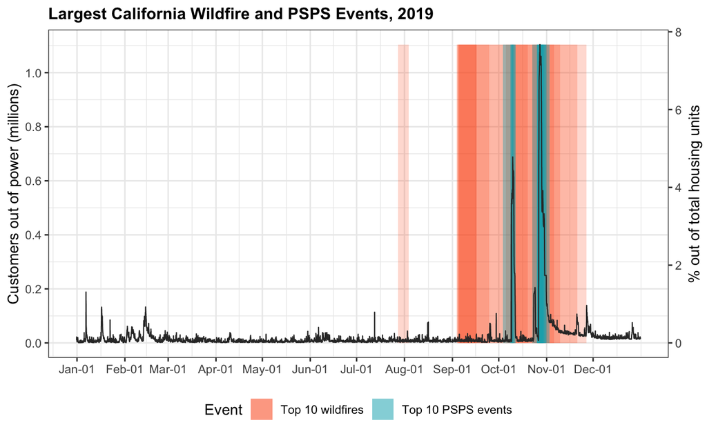

```r
fire_psps_df$date_stamp <- as.POSIXct(fire_psps_df$date_stamp,
                                     format = "%Y-%m-%d %H:%M:%S")
colors <- c("Fire" = "#FC4E07", "PSPS" = "#00AFBB")

p <- ggplot() +
      geom_rect(
    data = top10_fire_df,
    aes(
      xmin = as_datetime(Start),
      xmax = as_datetime(End),
      ymin = 0,
      ymax = max(ca_outage_df_hour$CustomersOutState),
      fill = "Fire"),
    color = NA,
    alpha = .2
  )+
    geom_rect(
    data = top10_psps_df,
    aes(
      xmin = as_datetime(Start),
      xmax = as_datetime(End),
      ymin = 0,
      ymax = max(ca_outage_df_hour$CustomersOutState),
      fill = "PSPS"
    ),
    color = NA,
    alpha = .4
  )+
  scale_fill_manual("Event",values = colors,labels = c("Top 10 wildfires","Top 10 PSPS events"))+
  geom_step(data = ca_outage_df_hour, aes(x = date, y = CustomersOutState),
            size = 0.4,color = "grey20") +
  # scale_x_datetime(date_breaks = "months" ,
  #                  date_labels = "%b-%d") +
  scale_x_datetime(breaks = breaks,
                   labels = format(breaks,"%b-%d"))+
  scale_y_continuous(
    breaks = caculate_class(ca_outage_df_hour$CustomersOutState, 5),
    labels = format(
      caculate_class(ca_outage_df_hour$CustomersOutState, 5)/1000000),
    sec.axis = sec_axis( trans=~./first(ca_outage_df_hour$TotalHUState)*100,
                         name="% out of total housing units")

  ) +
  labs(y = "Customers out of power (millions)")+
  ggtitle("Largest California Wildfire and PSPS Events, 2019")+
  # theme_ipsum()+
  theme_new+
    theme(legend.position="bottom",
          axis.title.x = element_blank(),
          plot.margin = unit(c(2,2,2,2), "mm"),
          plot.title = element_text(size = 12, face = "bold"),
          axis.title.y.right = element_text(angle = 90))




p
```

- Save plot `p` as an external file

```r
ggsave(
  here("plot", "02_ca_outage_timeseries.pdf"),
  plot = p,
  width = 8,
  height = 4,
  # dpi = 200,
  scale = 1
)
```

# Plot two large events in 2019

- Major Peak 2: PSPS + Kincade Fire (2019-10-23 to 2019-11-10)

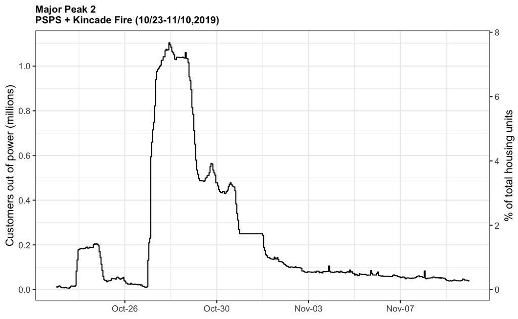

```r
p2 <- ggplot(subset(ca_outage_df_hour,date>=top10_fire_df$Start[1] & date<= top10_fire_df$End[1]),
       aes(x=date, y=CustomersOutState)) +
    geom_step() +
    scale_y_continuous(breaks = caculate_class(ca_outage_df_hour$CustomersOutState,5),
                       labels = format(round(caculate_class(ca_outage_df_hour$CustomersOutState,5)/1000000,1)),
                       sec.axis = sec_axis( trans=~./first(ca_outage_df_hour$TotalHUState)*100,
                                            name="% of total housing units"))+
    scale_x_datetime(date_breaks = "4 day" , date_labels = "%b-%d")+
    labs(x = "Time", y = "Customers out of power (millions)")+
    ggtitle("Major Peak 2\nPSPS + Kincade Fire (10/23-11/10,2019)")+
    # theme_ipsum()+
  theme_new+
    theme(axis.title.x = element_blank(),
          plot.margin = unit(c(2,2,2,2), "mm"),
          plot.title = element_text(size = 10, face = "bold"),
          axis.title.y.right = element_text( angle = 90))
p2
```

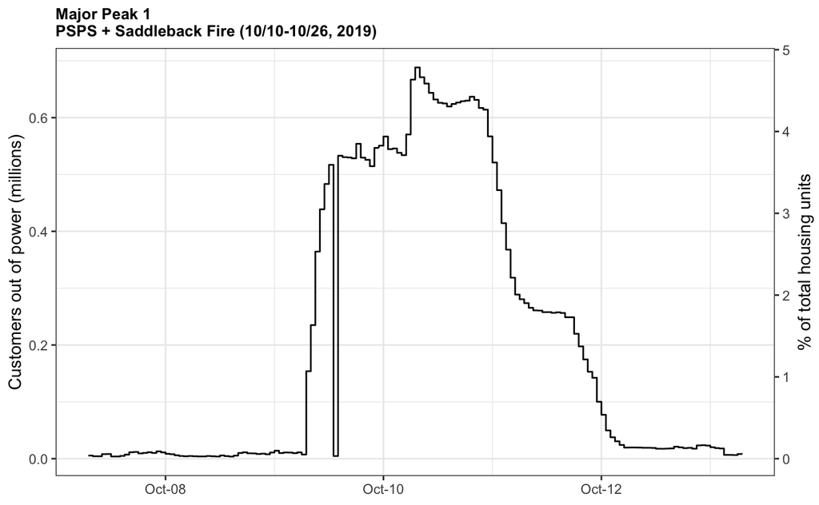

```r
p3 <- ggplot(subset(ca_outage_df_hour,date>="2019-10-07" & date<= "2019-10-13"),
       aes(x=date, y=CustomersOutState)) +
    geom_step() +
    scale_y_continuous(breaks = caculate_class(ca_outage_df_hour$CustomersOutState,5),
                       labels = format(round(caculate_class(ca_outage_df_hour$CustomersOutState,5)/1000000,1)),
                       sec.axis = sec_axis( trans=~./first(ca_outage_df_hour$TotalHUState)*100,
                                            name="% of total housing units"))+
    scale_x_datetime(date_breaks = "2 day" , date_labels = "%b-%d")+
    labs(x = "Time", y = "Customers out of power (millions)")+
    ggtitle("Major Peak 1\nPSPS + Saddleback Fire (10/10-10/26, 2019)")+
    theme_new+
  # theme_bw()+
    theme(axis.title.x = element_blank(),
          plot.title = element_text(size = 10, face = "bold"),
          axis.title.y.right = element_text( angle = 90))
p3
```

- Save to an external file

```r
library(patchwork)
layout <- "ABC"

p_all <- p3 + plot_spacer() + p2 +
    plot_layout(widths = c(4.5, 1 ,4.5),design = layout)
```

[output not shown]

```r
ggsave(
  here("plot","03_two_major_events.pdf"),
  p_all,
  # device = cairo_pdf,
  width = 10,
  height = 4,
  scale = 0.8
)
```